# 01_venn_rects

## 01_venn_rects

#### Question

1. Jason drew two overlapping rectangles on a 10x10 grid.

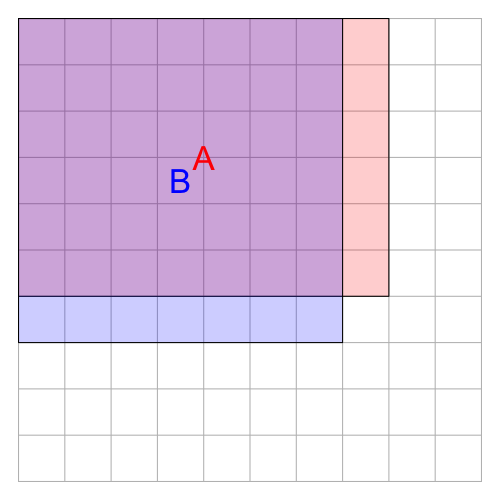

   Let’s call the red rectangle A and the blue rectangle B. Find the following areas:
   - Area covered by A = squares
   - Area covered by B = squares
   - Area covered by the intersection of A and B = squares
   - Area covered by the union of A and B = squares
   - Area covered by ONLY A (and not B) = squares
   - Area covered by ONLY B (and not A) = squares
   - Area not covered (neither A nor B) = squares

#### Question

2. Jason drew two overlapping rectangles on a 10x10 grid.

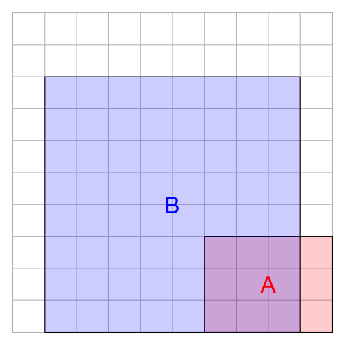

   Let’s call the red rectangle A and the blue rectangle B. Find the following areas:
   - Area covered by A = squares
   - Area covered by B = squares
   - Area covered by the intersection of A and B = squares
   - Area covered by the union of A and B = squares
   - Area covered by ONLY A (and not B) = squares
   - Area covered by ONLY B (and not A) = squares
   - Area not covered (neither A nor B) = squares

#### Question

3. Jason drew two overlapping rectangles on a 10x10 grid.

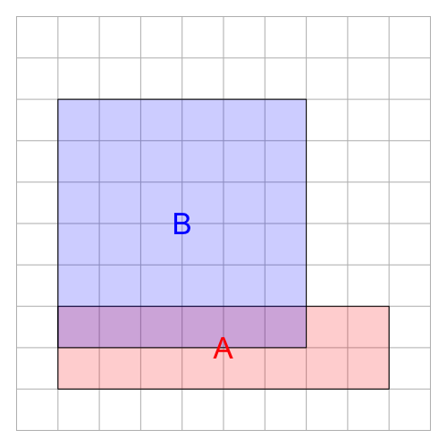

   Let’s call the red rectangle A and the blue rectangle B. Find the following areas:
   - Area covered by A = squares
   - Area covered by B = squares
   - Area covered by the intersection of A and B = squares
   - Area covered by the union of A and B = squares
   - Area covered by ONLY A (and not B) = squares
   - Area covered by ONLY B (and not A) = squares
   - Area not covered (neither A nor B) = squares

#### Question

4. Jason drew two overlapping rectangles on a 10x10 grid.

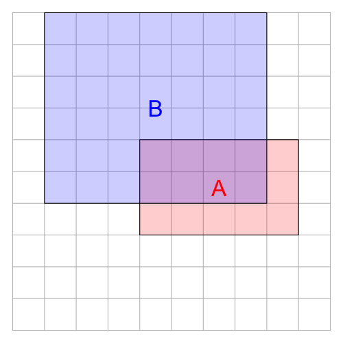

   Let’s call the red rectangle A and the blue rectangle B. Find the following areas:
   - Area covered by A = squares
   - Area covered by B = squares
   - Area covered by the intersection of A and B = squares
   - Area covered by the union of A and B = squares
   - Area covered by ONLY A (and not B) = squares
   - Area covered by ONLY B (and not A) = squares
   - Area not covered (neither A nor B) = squares

#### Question

5. Jason drew two overlapping rectangles on a 10x10 grid.

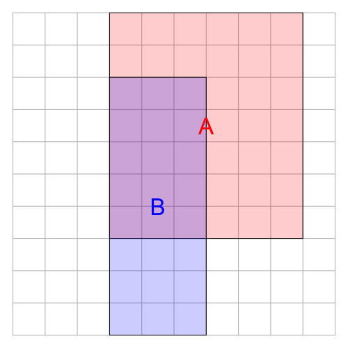

   Let’s call the red rectangle A and the blue rectangle B. Find the following areas:
   - Area covered by A = squares
   - Area covered by B = squares
   - Area covered by the intersection of A and B = squares
   - Area covered by the union of A and B = squares
   - Area covered by ONLY A (and not B) = squares
   - Area covered by ONLY B (and not A) = squares
   - Area not covered (neither A nor B) = squares

#### Question

6. Jason drew two overlapping rectangles on a 10x10 grid.

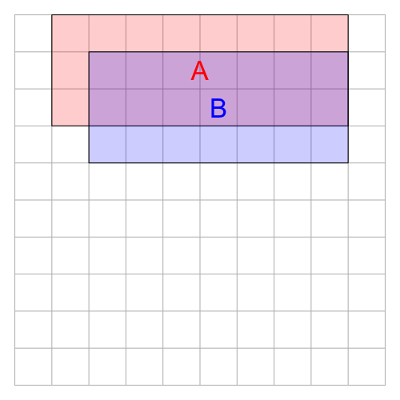

   Let’s call the red rectangle A and the blue rectangle B. Find the following areas:
   - Area covered by A = squares
   - Area covered by B = squares
   - Area covered by the intersection of A and B = squares
   - Area covered by the union of A and B = squares
   - Area covered by ONLY A (and not B) = squares
   - Area covered by ONLY B (and not A) = squares
   - Area not covered (neither A nor B) = squares

#### Question

7. Jason drew two overlapping rectangles on a 10x10 grid.

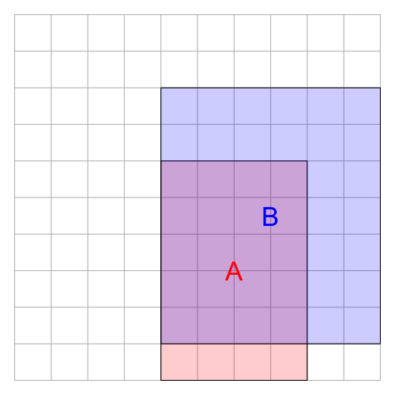

   Let’s call the red rectangle A and the blue rectangle B. Find the following areas:
   - Area covered by A = squares
   - Area covered by B = squares
   - Area covered by the intersection of A and B = squares
   - Area covered by the union of A and B = squares
   - Area covered by ONLY A (and not B) = squares
   - Area covered by ONLY B (and not A) = squares
   - Area not covered (neither A nor B) = squares

#### Question

8. Jason drew two overlapping rectangles on a 10x10 grid.

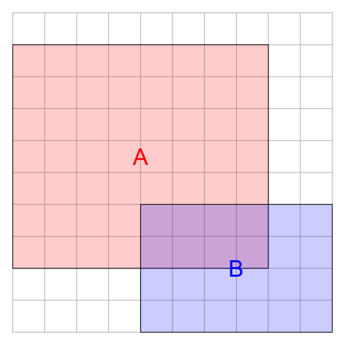

   Let’s call the red rectangle A and the blue rectangle B. Find the following areas:
   - Area covered by A = squares
   - Area covered by B = squares
   - Area covered by the intersection of A and B = squares
   - Area covered by the union of A and B = squares
   - Area covered by ONLY A (and not B) = squares
   - Area covered by ONLY B (and not A) = squares
   - Area not covered (neither A nor B) = squares